# Boosting: Trees and Gradient Boosting

Alípio Jorge

April 2021

# Boosting

What is the **basic idea** of boosting?

1. Learn a **(weak) model** from the data
   - meaning **better than random guessing**
2. See where it **mispredicts**
3. Learn a new model focusing on the mispredicted cases
4. **Combine** the learned models so far
5. Repeat the process from step 2 a fixed number of iterations

# Boosting > Summary

- What are we going to see in this lecture?
  - Boosting Trees using residuals
  - Gradient Boosting and pseudo-residuals

# Boosting

In summary:

- AdaBoost is **a form of boosting** for classification
- AdaBoost Classifier **can be derived from first principles** if exponential loss function is used

We will next see other forms of boosting

- In particular **gradient boosting**

# Boosting

Revising:

**What** is Boosting?

- Boosting combines **weak learners**
- So that the resulting combination is **arbitrarily good**
- One natural way to combine weak learners is **linear combination**

$$ f(x) = \sum_{m=1}^{M}{\beta_m . f_m(x;\theta_m)} $$

We can learn $\beta_m$ and $\theta_m$ minimizing a loss function.

- This is, in general, **too hard** to be computed
- So we resort to **Forward Stagewise Additive Modeling**
  - this can be done in different ways

# Boosting Trees

Suppose we want to find a **boosted regression** model using **trees**

For the (particular) case of trees, boosting has to find:

$$ \widetilde{\Theta} = {\arg\min}_{\Theta} \sum_{i=1}^{N}\widetilde{L}(y_i,T(x_i;\Theta)) $$

These parameters are the regions $R_j$ and the constants $\gamma_j$ of **each** tree

- This is still a **too difficult** optimization problem

# Boosting Trees

A popular algorithm for boosting regression trees goes as follows:

- We start by learning a decision tree $T_1(x) = f_1(x)$ with the original target values $y_i$
- We calculate the **residuals** $$r_i = y_i-T_1(x_i)$$
- We learn a new tree $T_2(x)$ now targetting $r_i$
- Now $$f_2(x_i) = f_1(x_i) + \lambda T_2(x_i)$$
  - $\lambda<1$ parameter reduces the step
- And we repeat the process $M$ times

# Boosting Trees

What is the intuition?

- Every new tree **models the residuals** and tries to **fix** the previous model
- In the limit, if the residuals are **zero**, the new tree has nothing to add.
- This also makes the new tree focus on **higher errors**
  - like AdaBoost
- $\lambda$ regulates the **speed** of fixing/learning. It is a hyper-parameter
  - Also called a **shrinkage** parameter
    - A learning step
  - The strength of the model **also** affects the speed of learning
    - A strong model provides **longer** steps

# Boosting Trees

Let us **formalize** the previous process.

The boosted tree is a sum of trees:

$$ f_M(x) = \sum_{m=1}^{M}\lambda T(x;\Theta_m) $$

The trees are induced using a **Forward Stagewise** approach

At each step, given the current model $~f_{m-1}(x)~$ one has to solve

$$ \widehat{\Theta}_m = (R_{jm}, \gamma_{jm}) = {\arg\min}_{\Theta_m} \sum_{i=1}^{N} L(y_i,f_{m-1}(x_i)+\lambda T(x_i;\Theta_m)) $$

- We focus on learning the **new tree** only (greedy approach)
- The regions $R_{jm}$ of the new tree are found as for any tree
- The $\gamma_{jm}$ is the mean of the residuals of $~f_{m-1}(x)~$ for the region $R_{jm}$

# Boosting Trees

- **Gradient Boosting** is a more powerful approach to boosting that sees the learning problem as an **optimization** one.
- The Regression Tree Boosting algorithm we saw has some features of **Gradient Boosting**.
- Let us see **how**.
- From the start
  - Our aim is to minimize $$ \sum_{i=1}^{N} L(y_i,f(x_i)) $$
  - With respect to $f$
- In general, we can use **Steepest Descent**.
  - Used to find **minima** (maxima) in a differentiable function
  - Follows the direction of the **negative gradient** of $L(f)$
  - The gradient is given by the derivative of $L$ at $f_{m-1}(x)$

# Boosting Trees

- Steepest descent is a **greedy strategy**
  - It does not consider alternatives
  - No backtracking
  - Computationally efficient
- **Tree boosting** already *kind of* follows that principle
  - The residuals give the gradient (how?)
    - If we use MSE, $Loss=\frac{1}{2}(y-f(x))^2$
    - $-\frac{\partial Loss}{\partial f(x)}=y-f(x) $
  - But the tree itself is built using a greedy strategy
    - Regions are not optimized independently of each other

# Gradient Boosting

The general form of gradient boosting is as follows.

- Initialize the model $f_0(x)$ with a constant value, e.g., the mean
- Iterate by building $f_m(x)$ as $f_{m-1}(x)+\gamma_m h_m(x)$
  - calculate the **gradient** of the loss function
  - this gives **direction**
  - fit $h_m(x)$ to the gradients of each point (akin to residuals)
  - optimize for $\gamma_m$

# Gradient Tree Boosting

The next algorithm adapts GB to Trees.

- $f_0(x)=mean(y)$
- For $m=1$ to $M$:
  - for each example $i$ $$ r_{im}=-\frac{\partial L(y_i,f(x_i))}{\partial f(x_i)} $$
  - $r_{im}$ are the **pseudo-residuals**
    - They are standard residuals with the Squared Error Loss
  - Fit a tree to $r_{im}$ and find regions $R_m$
  - For each region compute $$ \gamma_{jm} = \arg\min_{\gamma}\sum_{x_i \in R_{jm}} L(y_i,f_{m-1}(x_i)+\gamma)) $$
  - Update $$ f_m(x) = f_{m-1}(x)+\sum_{j} \gamma_{jm} I(x \in R_{jm}) $$
- Output $\widehat{f}(x) = f_M(x)$

(https://towardsdatascience.com/understanding-gradient-boosting-from-scratch-with-small-dataset-587592cc871f)

# Boosting > Overview

Overview:

- **Boosting** keeps adding models to "correct" the previous errors
- **Forward Stagewise Boosting** does this by focusing on the new model
- **Gradient Boosting** is a general solution derived from first principles
- **Gradient Tree Boosting** is specialized in trees and is different to general GB because instead of learning a single $\gamma$ per model, learns a $\gamma$ per model (tree) and region.

# Boosting

Example

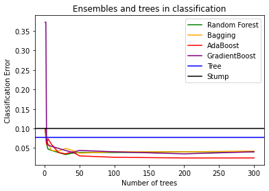

```python
from sklearn.datasets import load_breast_cancer
from sklearn.ensemble import AdaBoostClassifier as AdaC
from sklearn.ensemble import GradientBoostingClassifier as GBC
from sklearn.tree import DecisionTreeClassifier as DTC
from sklearn.ensemble import RandomForestClassifier as RFC
from sklearn.ensemble import BaggingClassifier as BagC
from sklearn.model_selection import cross_val_score
import matplotlib.pyplot as plt
import numpy as np

data=load_breast_cancer()
X=data.data
y=data.target

nfolds=5
RFfeat=np.int(np.sqrt(X.shape[1]))
ntree=np.array([1,2,3,5,10,20,30,40,50, 100, 200,300])


def score_gbc_class(m):
    model=GBC(n_estimators=m, learning_rate=0.1,max_depth=3)
    return np.mean(1-cross_val_score(model,X,y,cv=nfolds))

def score_ada_class(m):
    model=AdaC(n_estimators=m)
    return np.mean(1-cross_val_score(model,X,y,cv=nfolds))

def score_tree_class(depth=1):
    model=DTC(max_depth=depth)
    return np.mean(1-cross_val_score(model,X,y,cv=nfolds))

def score_rf_class(nt):
    model=RFC(n_estimators=nt, max_features=RFfeat)
    return np.mean(1-cross_val_score(model,X,y,cv=nfolds))

def score_bag_class(nt):
    model=BagC(n_estimators=nt)
    return np.mean(1-cross_val_score(model,X,y,cv=nfolds))


error_rf_class = list(map(score_rf_class,ntree))
error_bag_class = list(map(score_bag_class,ntree))
error_ada_class = list(map(score_ada_class,ntree))
error_gbc_class = list(map(score_gbc_class,ntree))

error_tree = score_tree_class(None)
error_decision_stump = score_tree_class(1)

error_decision_stump

plt.plot(ntree,error_rf_class,color='green')
plt.plot(ntree,error_bag_class,color='orange')
plt.plot(ntree,error_ada_class,color='red')
plt.plot(ntree,error_gbc_class,color='purple')
plt.axhline(error_tree, color='blue')
plt.axhline(error_decision_stump, color='black')
plt.legend(['Random Forest','Bagging','AdaBoost','GradientBoost','Tree','Stump'])
plt.xlabel('Number of trees')
plt.ylabel('Classification Error')
plt.title('Ensembles and trees in classification');
```

# Boosting

**Variable Importance** in a tree

- Similar to Random Forest
- "The (normalized) total reduction of the criterion brought by that feature. It is also known as the Gini importance."

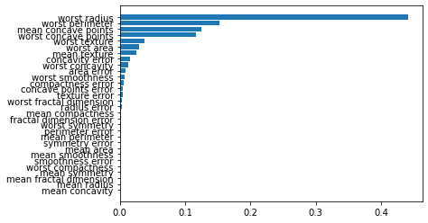

```python
model=GBC(n_estimators=100, learning_rate=0.1,max_depth=3).fit(X,y)

feat_imp=model.feature_importances_
feat_names=data.feature_names

feat_idx = np.argsort(feat_imp)
plt.barh(feat_names[feat_idx],feat_imp[feat_idx]);
```

# Boosting

**Important hyperparameters**

- Number of trees, tree depth and learning rate are hyperparameters that can be studied with a validation set or CV
  - Train error reduces with $M$ but we can incur in overfitting
- **Shrinkage** in gradient boosting: each model's answer is multiplied by a factor $0<\gamma \le 1$
  - $\gamma$ sets the **learning rate**
  - Smaller $\gamma$ is safer but learning process takes longer ($M$ has to be larger)
  - Default `learning_rate` in `sklearn`'s Gradient Boosting is 0.1

# Boosting

**Important hyperparameters**

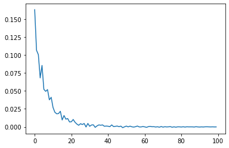

```python
model=GBC(n_estimators=100, learning_rate=0.1,max_depth=3,subsample=0.9).fit(X,y)
plt.plot(model.oob_improvement_);
```

# Activity

1. Use GradientBoosting on the Boston dataset to study the effect of tree depth and number of trees in the reduction of error, using cross-validation.
2. Plot horizontal lines with the performance of single models (tree, lm).
3. Use `sklearn`'s `oob_improvement_` to observe how the error of the model evolves with the iterations.

# Bibliography

- The Elements of Statistical Learning. Hastie, Trevor, Tibshirani, Robert, Friedman, Jerome. Springer.
- Greedy function approximation: A gradient boosting machine. Friedman, Jerome H. Ann. Statist. 29 (2001), no. 5, 1189--1232. doi:10.1214/aos/1013203451. https://projecteuclid.org/euclid.aos/1013203451
- An Introduction to Statistical Learning - with applications in R G. James, D. Witten, T. Hastie, R. Tibshirani, Springer 2013.
- Gradient Boosting, from Wikipedia, the free encyclopedia